# reg33

Michal Burdukiewicz

## AmyLoad annotations

Problematic peptide (two annotations in AmyLoad): VTQEFW.

## reg33

The reg33 dataset is used to benchmark PASTA2, specifically to assess the ability to detect hot spots in the sequences of whole proteins. This dataset was published [along with AMYLPRED2](http://journals.plos.org/plosone/article?id=10.1371/journal.pone.0054175).

[interactive chart not shown]

### Wrongly annotated sequences in reg33

Sequences (text):  
Small letters - hot spots as indicated by indices in publication.

Sequences (images):  
Bold text - hot spot.

#### Serum Amyloid A

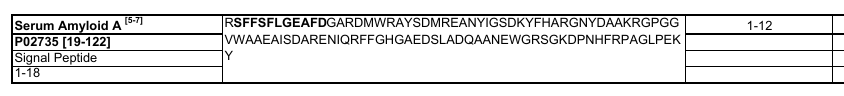

```
## rsffsflgeafdGARDMWRAYSDMREANYIGSDKYFHARG
## NYDAAKRGPGGVWAAEAISDARENIQRFFGHGAEDSLADQ
## AANEWGRSGKDPNHFRPAGLPEKY
```

#### β2-microglobulin

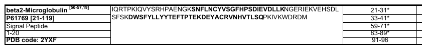

```
## IQRTPKIQVYSRHPAENGKSnflncyvsgfhPsdievdll
## kNGERIEKVEHSDLSFSKdwsfyllyyteftPTEKDEYAC
## RVnhvtlsqPkivkwdRDM
```

Image: **LSQ**PKIVKWDRDM  
Indices: **LSQ**P**KIVKWD**RDM

### reg33 vs AmyLoad

| AmyLoad_et | reg33_et | Count |
| --- | --- | --- |
| Non-amyloid | Non-amyloid | 265 |
| Amyloid | Non-amyloid | 17 |
| Non-amyloid | Amyloid | 24 |
| Amyloid | Amyloid | 77 |
| Non-amyloid | Mixed | 64 |
| Amyloid | Mixed | 16 |

463 peptides from AmyLoad are subsequences of proteins in reg33. 342 peptides have the same annotation in both datasets and the rest (121) have different annotations. The “Mixed” annotation means that in a peptide according to reg33 only a part of residues belongs to a hot spot.

| seq_name | seq | reg33_status | AmyLoad_et | reg33_et | CI |
| --- | --- | --- | --- | --- | --- |
| AMY18\|PHF6\|T-Protein | VQIVYK | 111111 | Amyloid | Amyloid | 0 |
| AMY38\|HABP16\|Amyloid | VHHQKLVFFAEDVGS | 111111111111111 | Amyloid | Amyloid | 0 |
| AMY42\|AB4\|Amyloid | HHQKLVFFAED | 11111111111 | Amyloid | Amyloid | 0 |
| AMY43\|AB5\|Amyloid | VHHQKLVFFAEDV | 1111111111111 | Amyloid | Amyloid | 0 |
| AMY44\|AB6\|Amyloid | EVHHQKLVFFAEDVG | 111111111111111 | Amyloid | Amyloid | 0 |
| AMY45\|AB7\|Amyloid | YEVHHQKLVFFAEDVGS | 01111111111111111 | Amyloid | Mixed | 0.0588235294117647 |
| AMY46\|AB8\|Amyloid | GYEVHHQKLVFFAEDVGSN | 0011111111111111111 | Amyloid | Mixed | 0.105263157894737 |
| AMY47\|AB9\|Amyloid | SGYEVHHQKLVFFAEDVGSNK | 000111111111111111111 | Amyloid | Mixed | 0.142857142857143 |
| AMY48\|AB10\|Amyloid | DSGYEVHHQKLVFFAEDVGSNKG | 00001111111111111111111 | Amyloid | Mixed | 0.173913043478261 |
| AMY49\|AB11\|Amyloid | HDSGYEVHHQKLVFFAEDVGSNKGA | 0000011111111111111111111 | Amyloid | Mixed | 0.2 |

[output cut: 453 more lines]

CI is concordance index, a difference of the average status of a protein in reg33 and a status in AmyLoad database. CI equal to 0 means that the sequences in both datasets have the same etiquette (amyloids/nonamyloid). CI equal to 1 means that a sequence has totally oppossed etiquettes. CI larger than 0.5 means that the bigger part of the sequence described in reg33 has the different annotation than in the AmyLoad database.

## Performance of AmyloGram on reg33

AmyloGram cannot be simply used to detect hot spots from reg33 proteins, because it does not predict if a single residue belongs to a hot spot, but rather assess the state of whole hexamer. To check te general performance of AmyloGram, we extracted overlapping hexamers from reg33 proteins. The state of the hexamer was equal to the state of majority of residues in the hexamer. For example, if four or more residues were belonging to a hot spot, the state of hexamer was assigned as “Amyloidogenic”.

The AUC of AmyloGram was **0.5585**, which is somehow expected since the algorithm was not trained on this type of data and is rather optimized to predict amyloidogenicity of peptides.

| Method | Sensitivity | Specificity | MCC |
| --- | --- | --- | --- |
| Aggrescan | 35.37 | 79.26 | 0.13 |
| AMYLPRED2 | 39.27 | 84.48 | 0.22 |
| FoldAmyloid (contacts) | 20.71 | 86.97 | 0.08 |
| FoldAmyloid (triple hybrid) | 19.21 | 86.22 | 0.06 |
| Tango | 13.67 | 95.57 | 0.14 |
| MetAmyl (high specificity) | 39.05 | 83.14 | 0.19 |
| MetAmyl (global accuracy) | 52.46 | 70.73 | 0.17 |
| FishAmyloid | 13.73 | 93.68 | 0.1 |
| PASTA 2.0 (90% specificity) | 30.24 | 90 | 0.22 |
| PASTA 2.0 (85% specificity) | 40.87 | 84.95 | 0.24 |

[output cut: 2 more lines]

### Length of sequences

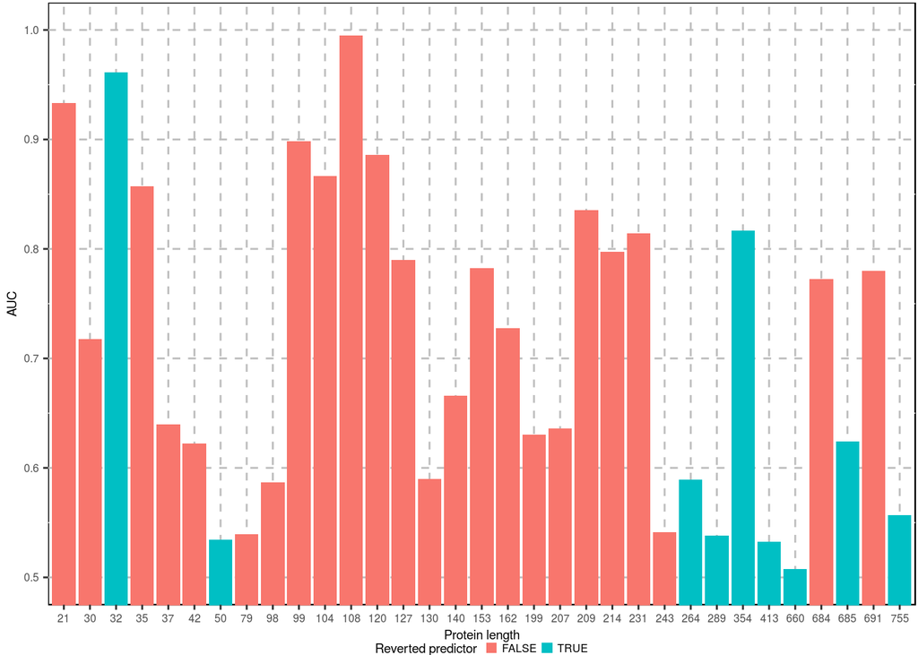

The performance of AUC seems to not depend on the length of analyzed proteins.

### Length of hot spots

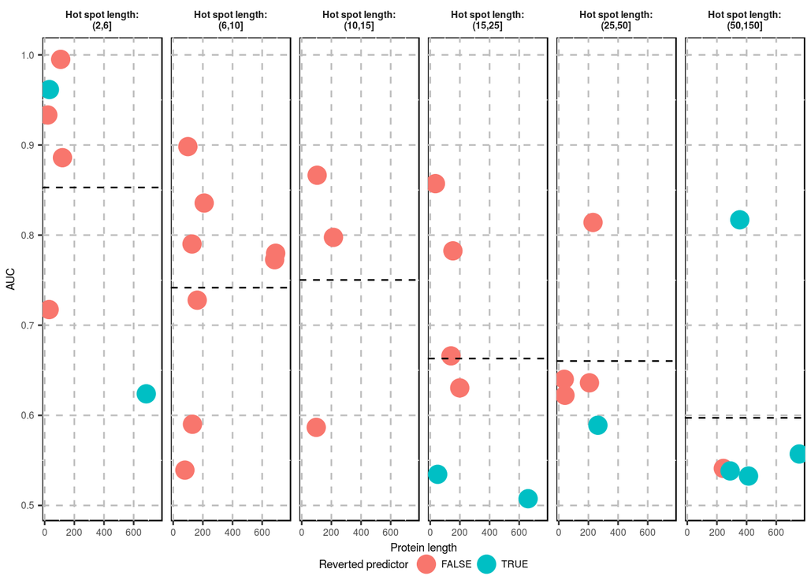

The prediction seems to be the worse for proteins with the longest hot spots. There are two possible explanations:

- AmyloGram cannot detect long hot spots;
- long hot spots were wrongly detected with experimental methods.

When proteins with hot spots longer than 26 are rmeoved from the data set, the general AUC is **0.7052**.